# PEC2_Visualizacion_CARLOS_TORO

Carlos Toro

2024-04-15

# 1 Comparativa en forma de histograma del total de emisiones de CO2 de los Paises China/USA/Rusia

# 2 Lectura del archivo

Leemos el CSV descargado:

```r
gpa <- as.data.frame(read.csv("GCB2022v27_MtCO2_flat.csv"))
```

# 3 Preparación de los datos

Ejecutamos los comandos necesarios de R para preparar nuestra visualización:

```r
gpa_usa1 <- gpa[gpa$Country=='USA',]
gpa_usa1 <- gpa_usa1[gpa_usa1$Year>1910 & gpa_usa1$Year<=2020,]
gpa_usa1$decade <- cut(gpa_usa1$Year, breaks = 11)

ed<-aggregate(Total~decade, data = gpa_usa1, sum)
a<-c(1910,1920,1930,1940,1950,1960,1970,1980,1990,2000,2010)
ed$decadeValue<-a

gpa_ch <- gpa[gpa$Country=='China',]
gpa_ch <- gpa_ch[gpa_ch$Year>1910 & gpa_ch$Year<=2020,]
gpa_ch$decade <- cut(gpa_ch$Year, breaks = 11)

ed_ch<-aggregate(Total~decade, data = gpa_ch, sum)
a<-c(1910,1920,1930,1940,1950,1960,1970,1980,1990,2000,2010)
ed_ch$decadeValue<-a

gpa_rus <- gpa[gpa$Country=='Russia',]
gpa_rus <- gpa_rus[gpa_rus$Year>1910 & gpa_rus$Year<=2020,]
gpa_rus$decade <- cut(gpa_rus$Year, breaks = 11)

ed_rus<-aggregate(Total~decade, data = gpa_rus, sum)
a<-c(1910,1920,1930,1940,1950,1960,1970,1980,1990,2000,2010)
ed_rus$decadeValue<-a

mx<-data.frame(ed$Total,ed_ch$Total, ed_rus$Total)
mx$decade <- ed$decadeValue
colours <- c('red','blue','green')
ylim <- c(0,max(mx[c('ed.Total','ed_ch.Total','ed_rus.Total')])*1.8)
```

## 3.1 Visualización

El siguiente histograma nos permite visualizar la comparativa de emisiones entre ambos paises:

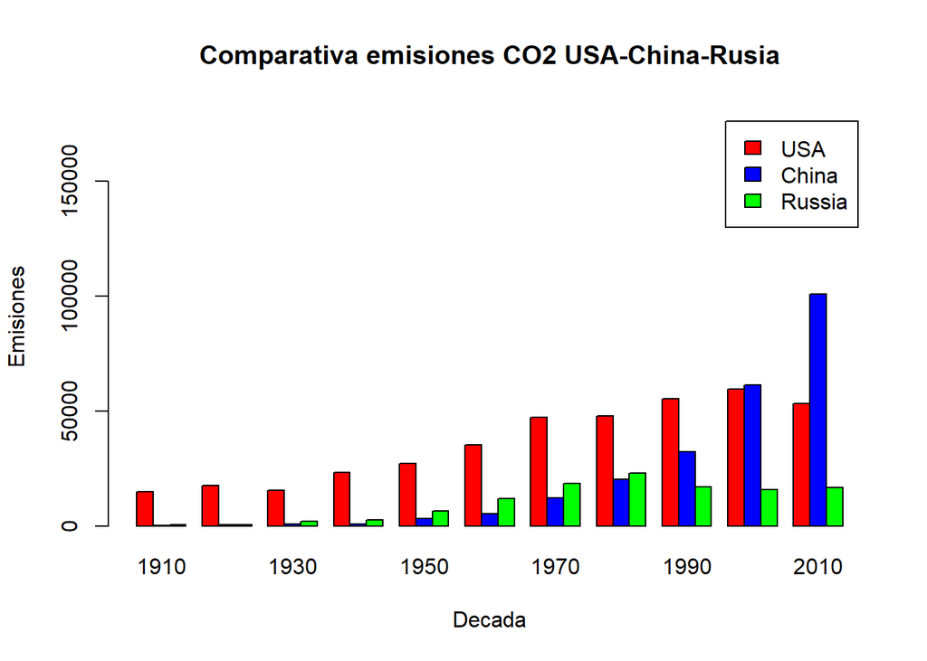

```r
barplot(t(mx[c('ed.Total', 'ed_ch.Total', 'ed_rus.Total')]),main='Comparativa emisiones CO2 USA-China-Rusia',ylab='Emisiones', xlab='Decada',beside = TRUE,
        col=colours, ylim=ylim, legend.text=c('USA','China', 'Russia'),names.arg = mx$decade)
```

De donde podemos obtener las siguientes conclusiones:

- China emite mucho mas CO2 en la actualidad que USA y Russia.
- En los años 90, China ha pasado a Rusia en emisiones de CO2.
- En los años 2000s China ha pasado a USA en emisiones de CO2
- En la historia, USA ha emitido mucho más CO2 que China, debido probablemente a la diferencia en los tiempos de crecimiento económico de cada país,. Esto como hemos comentado no es así en la actualidad, donde China es el mayor emisor de CO2 con diferencia.
- USA al igual que Rusia, han reducido sus emisiones en las ulimas décadas, debido probablem. debido a los acueerdos de Rio, Kioto y París. Acuerdos que vienen firmándose desde la década de los 90s.
- …

Volver a la página principal